# Práctica 3. Mapeo de secuencias cortas

Última actualización:

19 de marzo de 2026

# Preparación

Usaremos los programas siguientes:

- fastp (Chen et al. 2018). Si descargas el ejecutable en la carpeta actual, debes concederte el permiso de ejecución: `chmod u+x fastp`. Y además tendrás que invocarlo como `./fastp` para que Bash lo encuentre. Alternativamente, puedes copiarlo a una carpeta en tu `PATH`. Puedes consultar el `PATH` mediante `echo $PATH`. (/opt/homebrew/bin)
- bwa (Li y Durbin 2009). Puedes descargar el código fuente con y compilarlo siguiendo estos pasos:

  ```
  git clone https://github.com/lh3/bwa.git
  cd bwa
  make
  ```

  Puedes copiar el ejecutable a cualquier carpeta en tu `PATH` o bien, invocarlo con su dirección completa cada vez que quieras ejecutarlo.
- [samtools](https://www.htslib.org/), junto con `htslib` y `bcftools` (Danecek et al. 2021). Los tres programas pueden descargarse del mismo enlace, donde hay instrucciones para instalar la versión más reciente. Para algunos sistemas operativos existen paquetes propios, que pueden instalarse así: `apt install samtools`.
- [freebayes](https://github.com/freebayes/freebayes/releases) (Garrison y Marth 2012).

# Objetivos

1. Control de calidad de lecturas cortas.
2. Mapeo de lecturas cortas a un genoma de referencia.
3. Identificación de variantes.

# Datos

A continuación descargamos un par de archivos FASTQ de la base de datos [ENA](https://www.ebi.ac.uk/ena/browser/home). Han sido seleccionados porque su tamaño (comprimidos) no supera los 100 MB. Son secuencias de la cepa Tsu4-125 de *Bradyrhizobium japonicum* (bacteria simbionte de la planta de soja). Proceden de la [Universidad de Tohoku](https://www.tohoku.ac.jp/en/) y forman parte de un [proyecto](https://www.ebi.ac.uk/ena/browser/view/PRJDB3261) en el que se secuenciaron 16 cepas más de *Bradyrhizobium*.

```bash
if [ ! -e DRR025089_1.fastq.gz ]; then
   # Con la opción "-o /dev/null" nos deshacemos de los mensajes. (podemos ejecutarlo desde RStudio al configurarlo como working directory)
   wget -o /dev/null ftp://ftp.sra.ebi.ac.uk/vol1/fastq/DRR025/DRR025089/DRR025089_1.fastq.gz
fi
if [ ! -e DRR025089_2.fastq.gz ]; then
   wget -o /dev/null ftp://ftp.sra.ebi.ac.uk/vol1/fastq/DRR025/DRR025089/DRR025089_2.fastq.gz
fi
```

**NotaDesafío**

Una vez descargados los archivos FASTQ, échales un vistazo desde la línea de órdenes. Puedes hacerlo con `zless`, una versión de `less` capaz de mostrar archivos comprimidos, o bien descomprimiendo los archvios con `gunzip`. Para no ocupar espacio de disco innecesariamente, puedes usar `gunzip -c DRR025089_1.fastq.gz | less -S`, que envía el contenido del archivo a la salida estándar (-c indica que no debe crear un archivo nuevo descomprimido), de donde `less -S` lo lee, sin modificar nada en la carpeta. ¿Sabrías contar el número de líneas de cada archivo?

`gunzip -c DRR025089_1.fastq.gz | wc -l`

Esta orden sigue la misma lógica que lo explicado. Cuenta las líneas del archivo comprimido y muestra el número en el terminal sin necesidad de crear un nuevo archivo descomprimido.

Necesitaremos también el genoma de referencia de `Bradyrhizobium japonicum`. Usaremos el de la cepa ACCC 15027 (hay otros).

```bash
# Con la opción "-o /dev/null" nos deshacemos de los mensajes,
# y con "-O referencia.fa" escogemos un nombre adecuado para el archivo.
if [ ! -e referencia.fa ]; then
   wget -o /dev/null -O referencia.fa \
        https://www.ebi.ac.uk/ena/browser/api/fasta/GCA_042137995.2
fi
```

**NotaPreguntas**

- ¿Crees que deberíamos guardar los archivos descargados en `../../data`?

  Sí, porque simplemente son las secuencias que vamos a usar de base para el mapeo que haremos después. Lo que nos interesa es el resultado, no la secuencia de la que partimos.
- ¿Cómo podrías guardar los mensajes de `wget` en un archivo?

  El parámetro “-o” de wget permite recuperar los mensajes del archivo, pero al añadir la opción “/dev/null” le estamos especificando que queremos que los elimine. Por otra parte, el parámetro “-O” indica el nombre del archivo en el que vamos a descargar el contenido del enlace que añadimos a continuación.

  Por tanto, para redirigir los mensajes a un nuevo archivo y guardarlos podemos usar `wget -o archivo-mensajes -O referencia.fa enlace` para obtener tanto el genoma de referencia como un archivo que contenga sus mensajes.
- ¿De cuántas secuencias diferentes se compone este genoma de referencia?

  Al principio de cada secuencia hay un indicador con su nombre que empieza con >. Si contamos el número de líneas que empiezan con > sabremos el número de secuencias diferentes que hay en el archivo. Para eso hacemos `grep "^>" referencia.fa` . Esto nos muestra que además del genoma completo tiene 2 plásmidos.

# Control de calidad

```bash
if [ ! -e fastp.html ]; then
   # Si "fastp" está en la carpeta actual y no en el PATH, escribe "./fastp" en lugar de "fastp". (si tenemos fastp en un sitio diferente a donde estamos indicamos el camino hasta él. Lo mismo si el input está en una carpeta diferente)
   fastp -i DRR025089_1.fastq.gz \
         -o DRR025089_1_clean.fastq \
         -I DRR025089_2.fastq.gz \
         -O DRR025089_2_clean.fastq \
         --merge \
         --merged_out DRR025089_m_clean.fastq
fi
```

**NotaEjercicios**

1. Revisa la ayuda del programa ejecutando `fastp -h`, y asegúrate de entender al menos las opciones que hemos usado.

   -i y -I indican los 2 archivos de input, y -o y -O son sus correspondientes outputs filtrados después del control de calidad. La función –-merge fusiona las lecturas solapantes en una sola, y este resultado se exporta en un archivo especificado con –merge_out.
2. Revisa el informe generado por `fastp` en el archivo `fastp.html` y redacta un pequeño resumen de las principales conclusiones que sacas.

   El contenido de GC antes del filtrado es del 63.673652 %, y después es del 62.757142 %. Ambos datos son bastante cercanos al contenido de GC esperado para esta especie, que es alrededor del 64 %, por lo que podemos suponer que no ha habido contaminación y las muestras son correctas.

   Comparando los datos de Q20, Q30 y Q40 de antes y después del filtrado comprobamos que la calidad de las lecturas ha aumentado:

   |  | Antes | Después |
   | --- | --- | --- |
   | Q20 | 80.063669 % | 89.680239 % |
   | Q30 | 70.590064 % | 83.592194 % |
   | Q40 | 0.000076 % | 0.000110 % |

   El 91.330930 % de las lecturas pasaron el filtro de calidad (751.986000 K), y se corrigieron el 25.448769 % (209.536000 K) de lecturas y el 0.384317 % de bases (690.601000 K). El 8.541058 % de las lecturas (70.324000 K) eran de baja calidad, y el 0.128011 % (1.054000 K) tenían demasiadas N.
3. Descarga un segundo conjunto de archivos FASTQ de la misma especie y repite el análisis de calidad con ellos. Puedes ver algunas opciones en este enlace. Es mejor no descargar archivos demasiado grandes.

# Mapeo

El objetivo de esta sección es alinear las lecturas cortas al genoma de referencia, mediante el programa `bwa`. El archivo final será un archivo BAM *ordenado*. Para obtener ese archivo es necesario generar algunos archivos auxiliares: primero, el índice del genoma de referencia, después los alineamientos en formato SAM (no comprimidos) y finalmente un archivo BAM, que es la versión comprimida del SAM (todavía no ordenado). La jerarquía de condiciones de ejecución siguiente permitirá borrar los archivos auxiliares, para ahorrar espacio, y no tener que generarlos de nuevo cada vez que compilemos este documento si el archivo final ya está presente en la carpeta de trabajo.

```bash
if [ ! -e DRR025089.bam ]; then
   if [ ! -e DRR025089_unsorted.bam ]; then
      if [ ! -e DRR025089.sam ]; then
          if [ ! -e referencia.fa ]; then
             wget -o /dev/null -O referencia.fa \
        https://www.ebi.ac.uk/ena/browser/api/fasta/GCA_042137995.2
           fi
           if [ ! -e referencia.fa.bwt ]; then
            bwa index referencia.fa
           fi
         bwa mem -M -R '@RG\tID:DRR025089\tSM:SAMD00022947' \
                 -o DRR025089.sam \
                 referencia.fa \
                 ../../data/2026-02-10/DRR025089_1_clean.fastq \
                 ../../data/2026-02-10/DRR025089_2_clean.fastq \
         1> bwa.log 2> bwa.err
      fi
      samtools view -b -o DRR025089_unsorted.bam DRR025089.sam
    fi
    samtools sort -o DRR025089.bam DRR025089_unsorted.bam
    samtools index DRR025089.bam
    if [ -e DRR025089.bam ]; then
    rm referencia.fa
fi
```

```
bash: -c: line 24: syntax error: unexpected end of file
```

**NotaDesafíos**

1. Entre las órdenes anteriores, añade la descarga del genoma de referencia en el lugar adecuado y bajo la condición adecuada para que pueda borrarse una vez se haya generado el alineamiento.

   La descarga del genoma de referencia debería añadirse antes del condicional que lo usa. Al final de la secuencia de órdenes añadimos el comando para eliminar el archivo de referencia añadiendo la condición de que exista el archivo final resultante del mapeo (DRR025089.bam).
2. En un bloque de órdenes nuevo, alinea también los pares de lecturas cortas que `fastp` había combinado (`DR025089_m_clean.fastq`).

   ```bash
   if [ ! -e DRR025089_merged.bam ]; then
      if [ ! -e DRR025089_unsorted_merged.bam ]; then
         if [ ! -e DRR025089_merged.sam ]; then
             if [ ! -e referencia.fa ]; then
                wget -o /dev/null -O referencia.fa \
           https://www.ebi.ac.uk/ena/browser/api/fasta/GCA_042137995.2
              fi
              if [ ! -e referencia.fa.bwt ]; then
               bwa index referencia.fa
              fi
            bwa mem -M -R '@RG\tID:DRR025089\tSM:SAMD00022947' \
                    -o DRR025089_merged.sam \
                    referencia.fa \
                    ../../data/2026-02-10/DRR025089_m_clean.fastq \
            1> bwa_m.log 2> bwa_m.err
         fi
         samtools view -b -o DRR025089_unsorted_merged.bam DRR025089_merged.sam
       fi
       samtools sort -o DRR025089_merged.bam DRR025089_unsorted_merged.bam
       samtools index DRR025089_merged.bam
   fi
   ```

3. Lee la lista de funciones que te ofrece `samtools` al ejecutarlo sin ningún argumento. ¿Qué función usarías para combinar dos archvivos BAM en uno?

   `cat`, sirve para concatenar archivos BAM.
4. ¿Cuánto espacio de disco ocupan los archivos FASTQ, el genoma de referencia y su índice y el archivo SAM?

   Los archivos fastq en total ocupan 410 MB. El genoma de referencia y su índice ocupan 27,7 MB. El archivo SAM ocupa 191 MB.
5. Podíamos haber ahorrado algún paso aprovechando las *tuberías* de BASH:

```
bwa mem -M -R '@RG\tID:DRR025089\tSM:SAMD00022947' \
        referencia.fa DRR025089_1_clean.fastq DRR025089_2_clean.fastq | \
samtools view -u - | \
samtools sort - > DRR025089.bam
```

Este estilo tiene también la ventaja de ser más rápido. ¿Crees que hay algún inconveniente al usar las tuberías?

Es más difícil seguir el avance del proceso.

Antes de proseguir, es importante comprobar el resultado del paso anterior. Podemos extraer algunas estadísticas del archivo BAM así:

```bash
if [ ! -e DRR025089.stats.txt ]; then
   samtools stats DRR025089.bam > DRR025089.stats.txt
fi

# Extraemos la sección sobre profundidad de cobertura
if [ ! -e stat.$i.txt ]; then
   grep ^COV DRR025089.stats.txt | cut -f 2- > COV.txt
fi
```

Ahora podemos importar los datos de cobertura a una sesión de R y representarlos gráficamente:

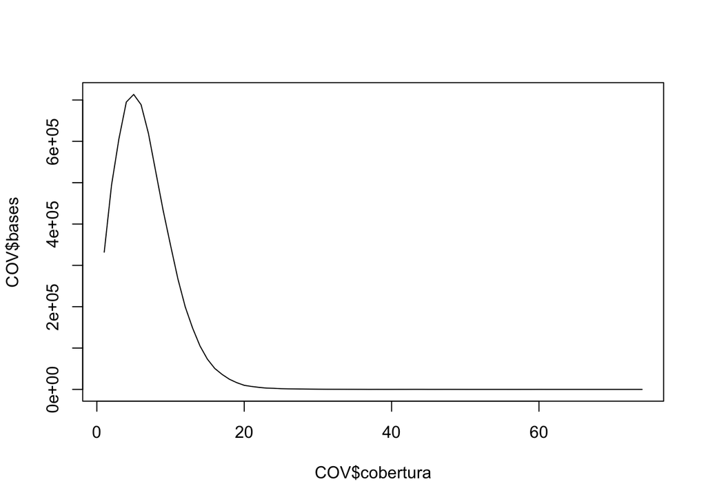

```r
COV <- read.table('COV.txt',
                  col.names = c('intervalo', 'cobertura', 'bases'))
plot(COV$cobertura, COV$bases, type = 'l')
```

**NotaDesafíos**

1. La distribución de cobertura tiene una cola larga. ¿Puedes centrar la representación gráfica entre 0 y 20? Pista: usa la opción `xlim` de `plot()`.

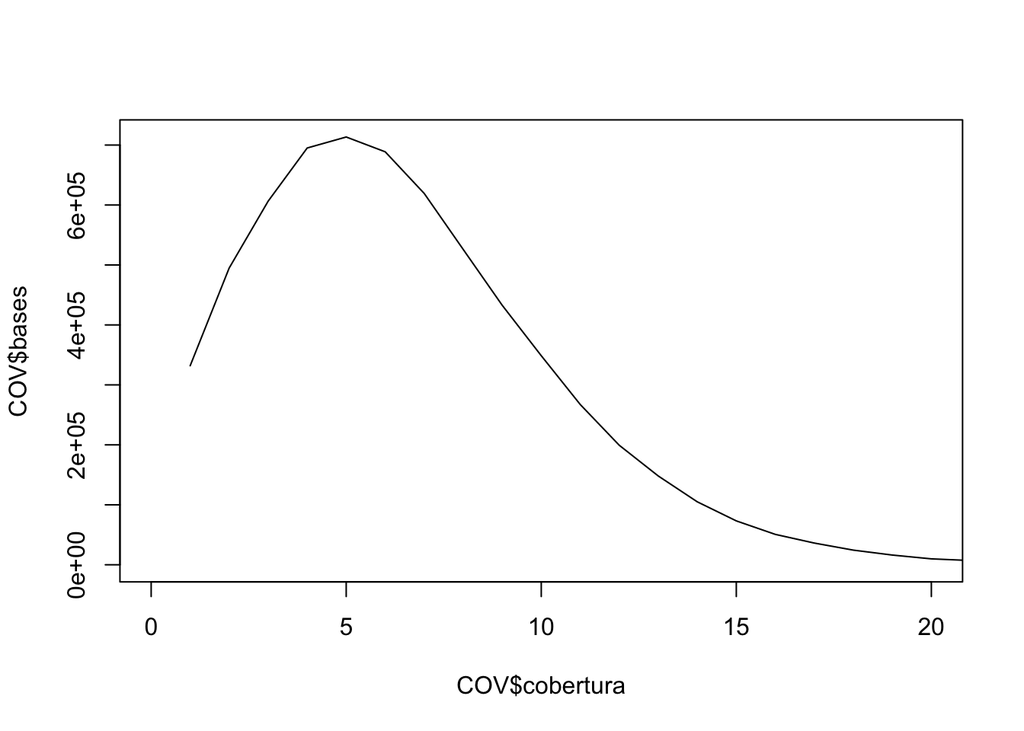

   ```r
   plot(COV$cobertura, COV$bases, type = 'l', xlim = c(0,20))
   ```

2. ¿Qué otras estadísticas crees que vale la pena revisar?

   También podríamos revisar el número de lecturas (samtools stats), las lecturas mapeadas (samtools flagstat) o la cobertura promedio (samtools depth)
3. El genoma de referencia incluye dos plásmidos. ¿La cepa secuenciada los tiene?

   Al tratarse de un archivo fastq cada línea empieza con @ y el identificador de la secuencia. En este caso las secuencias están marcadas como “@SQ”. Podemos ver las líneas que empiezan con ese identificador y ese será el número de secuencias contenidas en el archivo.

   `samtools view -H DRR025089.bam | grep -c "@SQ"`

```
samtools tview DRR025089.bam referencia.fa
```

# Identificación de variantes

```bash
if [ ! -e DRR025089.vcf ]; then
   freebayes -p 1 -f referencia.fa DRR025089.bam > DRR025089.vcf
fi
```

## Bibliografía

Chen, Shifu, Yanqing Zhou, Yaru Chen, y Jia Gu. 2018. «fastp: an ultra-fast all-in-one FASTQ preprocessor». *Bioinformatics* 34 (17): i884-90. https://doi.org/10.1093/bioinformatics/bty560.

Danecek, Petr, James K Bonfield, Jennifer Liddle, John Marshall, Valeriu Ohan, Martin O Pollard, Andrew Whitwham, et al. 2021. «Twelve years of SAMtools and BCFtools». *GigaScience* 10 (2). https://doi.org/10.1093/gigascience/giab008.

Garrison, E., y G. Marth. 2012. «Haplotype-based variant detection from short-read sequencing». https://arxiv.org/abs/1207.3907.

Li, Heng, y Richard Durbin. 2009. «Fast and accurate short read alignment with Burrows–Wheeler transform». *Bioinformatics* 25 (14): 1754-60. https://doi.org/10.1093/bioinformatics/btp324.